# Risk Factor Analysis

## Outcome Variable

**Outcome Variable:** ever_wasted

## Predictor Variables

**Intervention Variable:** mhtcm

**Adjustment Set:**

unadjusted

## Stratifying Variables

The analysis was stratified on these variable(s):

- agecat
- studyid
- country

## Data Summary

| agecat | studyid | country | mhtcm | ever_wasted | n_cell | n |
| --- | --- | --- | --- | --- | --- | --- |
| 0-24 months | ki0047075b-MAL-ED | BANGLADESH | >=155 cm | 0 | 19 | 254 |
| 0-24 months | ki0047075b-MAL-ED | BANGLADESH | >=155 cm | 1 | 6 | 254 |
| 0-24 months | ki0047075b-MAL-ED | BANGLADESH | <151 cm | 0 | 104 | 254 |
| 0-24 months | ki0047075b-MAL-ED | BANGLADESH | <151 cm | 1 | 59 | 254 |
| 0-24 months | ki0047075b-MAL-ED | BANGLADESH | [151-155) cm | 0 | 46 | 254 |
| 0-24 months | ki0047075b-MAL-ED | BANGLADESH | [151-155) cm | 1 | 20 | 254 |
| 0-24 months | ki0047075b-MAL-ED | BRAZIL | >=155 cm | 0 | 116 | 222 |
| 0-24 months | ki0047075b-MAL-ED | BRAZIL | >=155 cm | 1 | 14 | 222 |
| 0-24 months | ki0047075b-MAL-ED | BRAZIL | <151 cm | 0 | 49 | 222 |
| 0-24 months | ki0047075b-MAL-ED | BRAZIL | <151 cm | 1 | 4 | 222 |
| 0-24 months | ki0047075b-MAL-ED | BRAZIL | [151-155) cm | 0 | 38 | 222 |
| 0-24 months | ki0047075b-MAL-ED | BRAZIL | [151-155) cm | 1 | 1 | 222 |
| 0-24 months | ki0047075b-MAL-ED | INDIA | >=155 cm | 0 | 31 | 242 |
| 0-24 months | ki0047075b-MAL-ED | INDIA | >=155 cm | 1 | 24 | 242 |
| 0-24 months | ki0047075b-MAL-ED | INDIA | <151 cm | 0 | 57 | 242 |
| 0-24 months | ki0047075b-MAL-ED | INDIA | <151 cm | 1 | 58 | 242 |
| 0-24 months | ki0047075b-MAL-ED | INDIA | [151-155) cm | 0 | 39 | 242 |
| 0-24 months | ki0047075b-MAL-ED | INDIA | [151-155) cm | 1 | 33 | 242 |
| 0-24 months | ki0047075b-MAL-ED | NEPAL | >=155 cm | 0 | 34 | 238 |
| 0-24 months | ki0047075b-MAL-ED | NEPAL | >=155 cm | 1 | 7 | 238 |
| 0-24 months | ki0047075b-MAL-ED | NEPAL | <151 cm | 0 | 89 | 238 |
| 0-24 months | ki0047075b-MAL-ED | NEPAL | <151 cm | 1 | 44 | 238 |
| 0-24 months | ki0047075b-MAL-ED | NEPAL | [151-155) cm | 0 | 46 | 238 |
| 0-24 months | ki0047075b-MAL-ED | NEPAL | [151-155) cm | 1 | 18 | 238 |
| 0-24 months | ki0047075b-MAL-ED | PERU | >=155 cm | 0 | 57 | 290 |
| 0-24 months | ki0047075b-MAL-ED | PERU | >=155 cm | 1 | 3 | 290 |
| 0-24 months | ki0047075b-MAL-ED | PERU | <151 cm | 0 | 150 | 290 |
| 0-24 months | ki0047075b-MAL-ED | PERU | <151 cm | 1 | 19 | 290 |
| 0-24 months | ki0047075b-MAL-ED | PERU | [151-155) cm | 0 | 57 | 290 |
| 0-24 months | ki0047075b-MAL-ED | PERU | [151-155) cm | 1 | 4 | 290 |

[output cut: 378 more lines]

The following strata were considered:

- agecat: 0-24 months, studyid: ki0047075b-MAL-ED, country: BANGLADESH
- agecat: 0-24 months, studyid: ki0047075b-MAL-ED, country: BRAZIL
- agecat: 0-24 months, studyid: ki0047075b-MAL-ED, country: INDIA
- agecat: 0-24 months, studyid: ki0047075b-MAL-ED, country: NEPAL
- agecat: 0-24 months, studyid: ki0047075b-MAL-ED, country: PERU
- agecat: 0-24 months, studyid: ki0047075b-MAL-ED, country: SOUTH AFRICA
- agecat: 0-24 months, studyid: ki0047075b-MAL-ED, country: TANZANIA, UNITED REPUBLIC OF
- agecat: 0-24 months, studyid: ki1000304b-SAS-CompFeed, country: INDIA
- agecat: 0-24 months, studyid: ki1000304b-SAS-FoodSuppl, country: INDIA
- agecat: 0-24 months, studyid: ki1017093-NIH-Birth, country: BANGLADESH
- agecat: 0-24 months, studyid: ki1017093b-PROVIDE, country: BANGLADESH
- agecat: 0-24 months, studyid: ki1017093c-NIH-Crypto, country: BANGLADESH
- agecat: 0-24 months, studyid: ki1066203-TanzaniaChild2, country: TANZANIA, UNITED REPUBLIC OF
- agecat: 0-24 months, studyid: ki1101329-Keneba, country: GAMBIA
- agecat: 0-24 months, studyid: ki1112895-Guatemala BSC, country: GUATEMALA
- agecat: 0-24 months, studyid: ki1112895-iLiNS-Zinc, country: BURKINA FASO
- agecat: 0-24 months, studyid: ki1119695-PROBIT, country: BELARUS
- agecat: 0-24 months, studyid: ki1126311-ZVITAMBO, country: ZIMBABWE
- agecat: 0-24 months, studyid: ki1135781-COHORTS, country: GUATEMALA
- agecat: 0-24 months, studyid: ki1135781-COHORTS, country: INDIA
- agecat: 0-24 months, studyid: ki1135781-COHORTS, country: PHILIPPINES
- agecat: 0-24 months, studyid: ki1148112-LCNI-5, country: MALAWI
- agecat: 0-24 months, studyid: kiGH5241-JiVitA-3, country: BANGLADESH
- agecat: 0-6 months, studyid: ki0047075b-MAL-ED, country: BANGLADESH
- agecat: 0-6 months, studyid: ki0047075b-MAL-ED, country: BRAZIL
- agecat: 0-6 months, studyid: ki0047075b-MAL-ED, country: INDIA
- agecat: 0-6 months, studyid: ki0047075b-MAL-ED, country: NEPAL
- agecat: 0-6 months, studyid: ki0047075b-MAL-ED, country: PERU
- agecat: 0-6 months, studyid: ki0047075b-MAL-ED, country: SOUTH AFRICA
- agecat: 0-6 months, studyid: ki0047075b-MAL-ED, country: TANZANIA, UNITED REPUBLIC OF
- agecat: 0-6 months, studyid: ki1000304b-SAS-CompFeed, country: INDIA
- agecat: 0-6 months, studyid: ki1000304b-SAS-FoodSuppl, country: INDIA
- agecat: 0-6 months, studyid: ki1017093-NIH-Birth, country: BANGLADESH
- agecat: 0-6 months, studyid: ki1017093b-PROVIDE, country: BANGLADESH
- agecat: 0-6 months, studyid: ki1017093c-NIH-Crypto, country: BANGLADESH
- agecat: 0-6 months, studyid: ki1066203-TanzaniaChild2, country: TANZANIA, UNITED REPUBLIC OF
- agecat: 0-6 months, studyid: ki1101329-Keneba, country: GAMBIA
- agecat: 0-6 months, studyid: ki1112895-Guatemala BSC, country: GUATEMALA
- agecat: 0-6 months, studyid: ki1119695-PROBIT, country: BELARUS
- agecat: 0-6 months, studyid: ki1126311-ZVITAMBO, country: ZIMBABWE
- agecat: 0-6 months, studyid: ki1135781-COHORTS, country: GUATEMALA
- agecat: 0-6 months, studyid: ki1135781-COHORTS, country: INDIA
- agecat: 0-6 months, studyid: ki1135781-COHORTS, country: PHILIPPINES
- agecat: 0-6 months, studyid: ki1148112-LCNI-5, country: MALAWI
- agecat: 0-6 months, studyid: kiGH5241-JiVitA-3, country: BANGLADESH
- agecat: 6-24 months, studyid: ki0047075b-MAL-ED, country: BANGLADESH
- agecat: 6-24 months, studyid: ki0047075b-MAL-ED, country: BRAZIL
- agecat: 6-24 months, studyid: ki0047075b-MAL-ED, country: INDIA
- agecat: 6-24 months, studyid: ki0047075b-MAL-ED, country: NEPAL
- agecat: 6-24 months, studyid: ki0047075b-MAL-ED, country: PERU
- agecat: 6-24 months, studyid: ki0047075b-MAL-ED, country: SOUTH AFRICA
- agecat: 6-24 months, studyid: ki0047075b-MAL-ED, country: TANZANIA, UNITED REPUBLIC OF
- agecat: 6-24 months, studyid: ki1000304b-SAS-CompFeed, country: INDIA
- agecat: 6-24 months, studyid: ki1000304b-SAS-FoodSuppl, country: INDIA
- agecat: 6-24 months, studyid: ki1017093-NIH-Birth, country: BANGLADESH
- agecat: 6-24 months, studyid: ki1017093b-PROVIDE, country: BANGLADESH
- agecat: 6-24 months, studyid: ki1017093c-NIH-Crypto, country: BANGLADESH
- agecat: 6-24 months, studyid: ki1066203-TanzaniaChild2, country: TANZANIA, UNITED REPUBLIC OF
- agecat: 6-24 months, studyid: ki1101329-Keneba, country: GAMBIA
- agecat: 6-24 months, studyid: ki1112895-Guatemala BSC, country: GUATEMALA
- agecat: 6-24 months, studyid: ki1112895-iLiNS-Zinc, country: BURKINA FASO
- agecat: 6-24 months, studyid: ki1119695-PROBIT, country: BELARUS
- agecat: 6-24 months, studyid: ki1126311-ZVITAMBO, country: ZIMBABWE
- agecat: 6-24 months, studyid: ki1135781-COHORTS, country: GUATEMALA
- agecat: 6-24 months, studyid: ki1135781-COHORTS, country: INDIA
- agecat: 6-24 months, studyid: ki1135781-COHORTS, country: PHILIPPINES
- agecat: 6-24 months, studyid: ki1148112-LCNI-5, country: MALAWI
- agecat: 6-24 months, studyid: kiGH5241-JiVitA-3, country: BANGLADESH

### Dropped Strata

Some strata were dropped due to rare outcomes:

- agecat: 0-24 months, studyid: ki0047075b-MAL-ED, country: BRAZIL
- agecat: 0-24 months, studyid: ki0047075b-MAL-ED, country: PERU
- agecat: 0-24 months, studyid: ki0047075b-MAL-ED, country: SOUTH AFRICA
- agecat: 0-24 months, studyid: ki1112895-Guatemala BSC, country: GUATEMALA
- agecat: 0-6 months, studyid: ki0047075b-MAL-ED, country: BRAZIL
- agecat: 0-6 months, studyid: ki0047075b-MAL-ED, country: NEPAL
- agecat: 0-6 months, studyid: ki0047075b-MAL-ED, country: PERU
- agecat: 0-6 months, studyid: ki0047075b-MAL-ED, country: SOUTH AFRICA
- agecat: 0-6 months, studyid: ki0047075b-MAL-ED, country: TANZANIA, UNITED REPUBLIC OF
- agecat: 0-6 months, studyid: ki1112895-Guatemala BSC, country: GUATEMALA
- agecat: 0-6 months, studyid: ki1148112-LCNI-5, country: MALAWI
- agecat: 6-24 months, studyid: ki0047075b-MAL-ED, country: BANGLADESH
- agecat: 6-24 months, studyid: ki0047075b-MAL-ED, country: BRAZIL
- agecat: 6-24 months, studyid: ki0047075b-MAL-ED, country: PERU
- agecat: 6-24 months, studyid: ki0047075b-MAL-ED, country: SOUTH AFRICA
- agecat: 6-24 months, studyid: ki1112895-Guatemala BSC, country: GUATEMALA
- agecat: 6-24 months, studyid: ki1119695-PROBIT, country: BELARUS

## Methods Detail

We’re interested in the causal parameters $E[Y_a]$ for all values of $a \in \mathcal{A}$. These parameters represent the mean outcome if, possibly contrary to fact, we intervened to set all units to have $A=a$. Under the randomization and positivity assumptions, these are identified by the statistical parameters $\psi_a=E_W[E_{Y|A,W}(Y|A=a,W)]$. In addition, we’re interested in the mean of $Y$, $E[Y]$ under no intervention (the observed mean). We will estimate these parameters by using SuperLearner to fit the relevant likelihood factors – $E_{Y|A,W}(Y|A=a,W)$ and $p(A=a|W)$, and then updating our likelihood fit using a joint TMLE.

For unadjusted analyses ($W=\{\}$), initial likelihoods were estimated using Lrnr_glm to estimate the simple $E(Y|A)$ and Lrnr_mean to estimate $p(A)$. For adjusted analyses, a small library containing Lrnr_glmnet, Lrnr_xgboost, and Lrnr_mean was used.

Having estimated these parameters, we will then use the delta method to estimate relative risks and attributable risks relative to a prespecified baseline level of $A$.

# Results Detail

## Results Plots

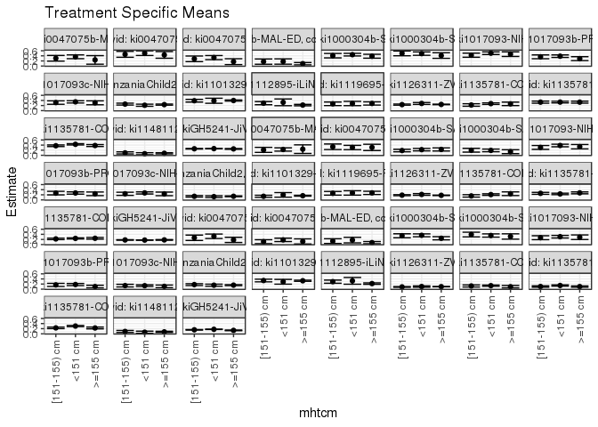

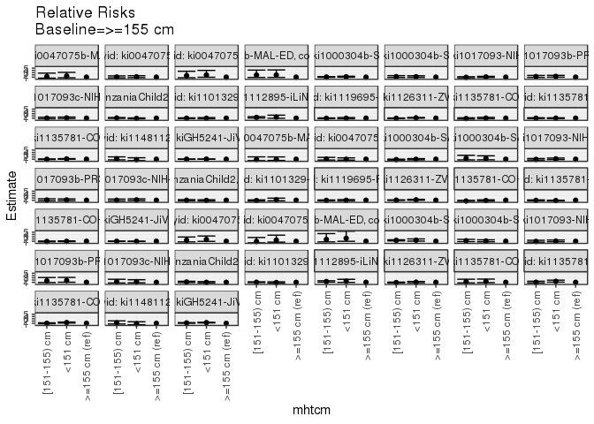

[figure not shown]

[figure not shown]

## Results Table

### Parameter: TSM

| agecat | studyid | country | intervention_level | baseline_level | estimate | ci_lower | ci_upper |
| --- | --- | --- | --- | --- | --- | --- | --- |
| 0-24 months | ki0047075b-MAL-ED | BANGLADESH | >=155 cm | NA | 0.2400000 | 0.0722560 | 0.4077440 |
| 0-24 months | ki0047075b-MAL-ED | BANGLADESH | <151 cm | NA | 0.3619632 | 0.2880425 | 0.4358839 |
| 0-24 months | ki0047075b-MAL-ED | BANGLADESH | [151-155) cm | NA | 0.3030303 | 0.1919383 | 0.4141223 |
| 0-24 months | ki0047075b-MAL-ED | INDIA | >=155 cm | NA | 0.4363636 | 0.3050259 | 0.5677014 |
| 0-24 months | ki0047075b-MAL-ED | INDIA | <151 cm | NA | 0.5043478 | 0.4127781 | 0.5959176 |
| 0-24 months | ki0047075b-MAL-ED | INDIA | [151-155) cm | NA | 0.4583333 | 0.3430045 | 0.5736621 |
| 0-24 months | ki0047075b-MAL-ED | NEPAL | >=155 cm | NA | 0.1707317 | 0.0553133 | 0.2861501 |
| 0-24 months | ki0047075b-MAL-ED | NEPAL | <151 cm | NA | 0.3308271 | 0.2506950 | 0.4109591 |
| 0-24 months | ki0047075b-MAL-ED | NEPAL | [151-155) cm | NA | 0.2812500 | 0.1708656 | 0.3916344 |
| 0-24 months | ki0047075b-MAL-ED | TANZANIA, UNITED REPUBLIC OF | >=155 cm | NA | 0.0915033 | 0.0457279 | 0.1372787 |
| 0-24 months | ki0047075b-MAL-ED | TANZANIA, UNITED REPUBLIC OF | <151 cm | NA | 0.1764706 | 0.0716399 | 0.2813013 |
| 0-24 months | ki0047075b-MAL-ED | TANZANIA, UNITED REPUBLIC OF | [151-155) cm | NA | 0.1730769 | 0.0700505 | 0.2761033 |
| 0-24 months | ki1000304b-SAS-CompFeed | INDIA | >=155 cm | NA | 0.3838028 | 0.3072646 | 0.4603410 |
| 0-24 months | ki1000304b-SAS-CompFeed | INDIA | <151 cm | NA | 0.4455852 | 0.3941372 | 0.4970332 |
| 0-24 months | ki1000304b-SAS-CompFeed | INDIA | [151-155) cm | NA | 0.4059701 | 0.3193613 | 0.4925790 |
| 0-24 months | ki1000304b-SAS-FoodSuppl | INDIA | >=155 cm | NA | 0.4102564 | 0.3009636 | 0.5195492 |
| 0-24 months | ki1000304b-SAS-FoodSuppl | INDIA | <151 cm | NA | 0.4863636 | 0.4202370 | 0.5524903 |
| 0-24 months | ki1000304b-SAS-FoodSuppl | INDIA | [151-155) cm | NA | 0.4954955 | 0.4023696 | 0.5886214 |
| 0-24 months | ki1017093-NIH-Birth | BANGLADESH | >=155 cm | NA | 0.4655172 | 0.3746720 | 0.5563625 |
| 0-24 months | ki1017093-NIH-Birth | BANGLADESH | <151 cm | NA | 0.5027624 | 0.4512152 | 0.5543097 |
| 0-24 months | ki1017093-NIH-Birth | BANGLADESH | [151-155) cm | NA | 0.4246575 | 0.3444154 | 0.5048997 |
| 0-24 months | ki1017093b-PROVIDE | BANGLADESH | >=155 cm | NA | 0.2898551 | 0.2141025 | 0.3656076 |
| 0-24 months | ki1017093b-PROVIDE | BANGLADESH | <151 cm | NA | 0.3860590 | 0.3366155 | 0.4355024 |
| 0-24 months | ki1017093b-PROVIDE | BANGLADESH | [151-155) cm | NA | 0.3607595 | 0.2858244 | 0.4356946 |
| 0-24 months | ki1017093c-NIH-Crypto | BANGLADESH | >=155 cm | NA | 0.3071429 | 0.2306776 | 0.3836081 |
| 0-24 months | ki1017093c-NIH-Crypto | BANGLADESH | <151 cm | NA | 0.3448276 | 0.3001314 | 0.3895237 |
| 0-24 months | ki1017093c-NIH-Crypto | BANGLADESH | [151-155) cm | NA | 0.3166667 | 0.2486654 | 0.3846680 |
| 0-24 months | ki1066203-TanzaniaChild2 | TANZANIA, UNITED REPUBLIC OF | >=155 cm | NA | 0.2362416 | 0.2146690 | 0.2578142 |
| 0-24 months | ki1066203-TanzaniaChild2 | TANZANIA, UNITED REPUBLIC OF | <151 cm | NA | 0.2122905 | 0.1699216 | 0.2546594 |
| 0-24 months | ki1066203-TanzaniaChild2 | TANZANIA, UNITED REPUBLIC OF | [151-155) cm | NA | 0.2563601 | 0.2184952 | 0.2942249 |

[output cut: 123 more lines]

### Parameter: E(Y)

| agecat | studyid | country | intervention_level | baseline_level | estimate | ci_lower | ci_upper |
| --- | --- | --- | --- | --- | --- | --- | --- |
| 0-24 months | ki0047075b-MAL-ED | BANGLADESH | NA | NA | 0.3346457 | 0.2765014 | 0.3927899 |
| 0-24 months | ki0047075b-MAL-ED | INDIA | NA | NA | 0.4752066 | 0.4121581 | 0.5382551 |
| 0-24 months | ki0047075b-MAL-ED | NEPAL | NA | NA | 0.2899160 | 0.2321510 | 0.3476810 |
| 0-24 months | ki0047075b-MAL-ED | TANZANIA, UNITED REPUBLIC OF | NA | NA | 0.1250000 | 0.0844083 | 0.1655917 |
| 0-24 months | ki1000304b-SAS-CompFeed | INDIA | NA | NA | 0.4107914 | 0.3512139 | 0.4703688 |
| 0-24 months | ki1000304b-SAS-FoodSuppl | INDIA | NA | NA | 0.4743276 | 0.4258753 | 0.5227800 |
| 0-24 months | ki1017093-NIH-Birth | BANGLADESH | NA | NA | 0.4775641 | 0.4383415 | 0.5167867 |
| 0-24 months | ki1017093b-PROVIDE | BANGLADESH | NA | NA | 0.3602392 | 0.3238339 | 0.3966444 |
| 0-24 months | ki1017093c-NIH-Crypto | BANGLADESH | NA | NA | 0.3311258 | 0.2975342 | 0.3647175 |
| 0-24 months | ki1066203-TanzaniaChild2 | TANZANIA, UNITED REPUBLIC OF | NA | NA | 0.2369648 | 0.2198019 | 0.2541277 |
| 0-24 months | ki1101329-Keneba | GAMBIA | NA | NA | 0.3958076 | 0.3763721 | 0.4152432 |
| 0-24 months | ki1112895-iLiNS-Zinc | BURKINA FASO | NA | NA | 0.2271869 | 0.2003867 | 0.2539871 |
| 0-24 months | ki1119695-PROBIT | BELARUS | NA | NA | 0.2816368 | 0.2197012 | 0.3435724 |
| 0-24 months | ki1126311-ZVITAMBO | ZIMBABWE | NA | NA | 0.2447609 | 0.2362612 | 0.2532607 |
| 0-24 months | ki1135781-COHORTS | GUATEMALA | NA | NA | 0.2627451 | 0.2385772 | 0.2869130 |
| 0-24 months | ki1135781-COHORTS | INDIA | NA | NA | 0.3338583 | 0.3126757 | 0.3550409 |
| 0-24 months | ki1135781-COHORTS | PHILIPPINES | NA | NA | 0.4036125 | 0.3861835 | 0.4210415 |
| 0-24 months | ki1148112-LCNI-5 | MALAWI | NA | NA | 0.0788530 | 0.0605839 | 0.0971222 |
| 0-24 months | kiGH5241-JiVitA-3 | BANGLADESH | NA | NA | 0.2581222 | 0.2516585 | 0.2645860 |
| 0-6 months | ki0047075b-MAL-ED | BANGLADESH | NA | NA | 0.2244094 | 0.1730022 | 0.2758167 |
| 0-6 months | ki0047075b-MAL-ED | INDIA | NA | NA | 0.3140496 | 0.2554513 | 0.3726479 |
| 0-6 months | ki1000304b-SAS-CompFeed | INDIA | NA | NA | 0.2154736 | 0.1691818 | 0.2617655 |
| 0-6 months | ki1000304b-SAS-FoodSuppl | INDIA | NA | NA | 0.1833741 | 0.1458251 | 0.2209231 |
| 0-6 months | ki1017093-NIH-Birth | BANGLADESH | NA | NA | 0.3569132 | 0.3192325 | 0.3945938 |
| 0-6 months | ki1017093b-PROVIDE | BANGLADESH | NA | NA | 0.2630792 | 0.2296894 | 0.2964690 |
| 0-6 months | ki1017093c-NIH-Crypto | BANGLADESH | NA | NA | 0.2582781 | 0.2270370 | 0.2895193 |
| 0-6 months | ki1066203-TanzaniaChild2 | TANZANIA, UNITED REPUBLIC OF | NA | NA | 0.1394659 | 0.1254831 | 0.1534487 |
| 0-6 months | ki1101329-Keneba | GAMBIA | NA | NA | 0.1622128 | 0.1465647 | 0.1778610 |
| 0-6 months | ki1119695-PROBIT | BELARUS | NA | NA | 0.2746469 | 0.2119817 | 0.3373120 |
| 0-6 months | ki1126311-ZVITAMBO | ZIMBABWE | NA | NA | 0.1822082 | 0.1745617 | 0.1898546 |
| 0-6 months | ki1135781-COHORTS | GUATEMALA | NA | NA | 0.2019139 | 0.1775635 | 0.2262643 |
| 0-6 months | ki1135781-COHORTS | INDIA | NA | NA | 0.2528180 | 0.2330767 | 0.2725593 |
| 0-6 months | ki1135781-COHORTS | PHILIPPINES | NA | NA | 0.2355453 | 0.2204685 | 0.2506222 |
| 0-6 months | kiGH5241-JiVitA-3 | BANGLADESH | NA | NA | 0.1763452 | 0.1707264 | 0.1819640 |
| 6-24 months | ki0047075b-MAL-ED | INDIA | NA | NA | 0.2735043 | 0.2162683 | 0.3307402 |
| 6-24 months | ki0047075b-MAL-ED | NEPAL | NA | NA | 0.1531915 | 0.1070438 | 0.1993392 |
| 6-24 months | ki0047075b-MAL-ED | TANZANIA, UNITED REPUBLIC OF | NA | NA | 0.1061224 | 0.0674772 | 0.1447677 |
| 6-24 months | ki1000304b-SAS-CompFeed | INDIA | NA | NA | 0.3077525 | 0.2591695 | 0.3563356 |
| 6-24 months | ki1000304b-SAS-FoodSuppl | INDIA | NA | NA | 0.3566085 | 0.3096676 | 0.4035494 |
| 6-24 months | ki1017093-NIH-Birth | BANGLADESH | NA | NA | 0.2939002 | 0.2554778 | 0.3323226 |
| 6-24 months | ki1017093b-PROVIDE | BANGLADESH | NA | NA | 0.1612378 | 0.1321259 | 0.1903497 |
| 6-24 months | ki1017093c-NIH-Crypto | BANGLADESH | NA | NA | 0.1315068 | 0.1069744 | 0.1560393 |
| 6-24 months | ki1066203-TanzaniaChild2 | TANZANIA, UNITED REPUBLIC OF | NA | NA | 0.1617128 | 0.1455117 | 0.1779140 |
| 6-24 months | ki1101329-Keneba | GAMBIA | NA | NA | 0.3288908 | 0.3097941 | 0.3479875 |
| 6-24 months | ki1112895-iLiNS-Zinc | BURKINA FASO | NA | NA | 0.2271869 | 0.2003867 | 0.2539871 |
| 6-24 months | ki1126311-ZVITAMBO | ZIMBABWE | NA | NA | 0.0964361 | 0.0901919 | 0.1026803 |
| 6-24 months | ki1135781-COHORTS | GUATEMALA | NA | NA | 0.1288927 | 0.1095683 | 0.1482172 |
| 6-24 months | ki1135781-COHORTS | INDIA | NA | NA | 0.1199132 | 0.1050778 | 0.1347486 |
| 6-24 months | ki1135781-COHORTS | PHILIPPINES | NA | NA | 0.2666429 | 0.2502871 | 0.2829988 |
| 6-24 months | ki1148112-LCNI-5 | MALAWI | NA | NA | 0.0765492 | 0.0583736 | 0.0947248 |
| 6-24 months | kiGH5241-JiVitA-3 | BANGLADESH | NA | NA | 0.1637386 | 0.1576238 | 0.1698535 |

### Parameter: RR

| agecat | studyid | country | intervention_level | baseline_level | estimate | ci_lower | ci_upper |
| --- | --- | --- | --- | --- | --- | --- | --- |
| 0-24 months | ki0047075b-MAL-ED | BANGLADESH | >=155 cm | >=155 cm | 1.0000000 | 1.0000000 | 1.0000000 |
| 0-24 months | ki0047075b-MAL-ED | BANGLADESH | <151 cm | >=155 cm | 1.5081800 | 0.7281453 | 3.1238365 |
| 0-24 months | ki0047075b-MAL-ED | BANGLADESH | [151-155) cm | >=155 cm | 1.2626263 | 0.5734697 | 2.7799639 |
| 0-24 months | ki0047075b-MAL-ED | INDIA | >=155 cm | >=155 cm | 1.0000000 | 1.0000000 | 1.0000000 |
| 0-24 months | ki0047075b-MAL-ED | INDIA | <151 cm | >=155 cm | 1.1557971 | 0.8132528 | 1.6426219 |
| 0-24 months | ki0047075b-MAL-ED | INDIA | [151-155) cm | >=155 cm | 1.0503472 | 0.7095047 | 1.5549288 |
| 0-24 months | ki0047075b-MAL-ED | NEPAL | >=155 cm | >=155 cm | 1.0000000 | 1.0000000 | 1.0000000 |
| 0-24 months | ki0047075b-MAL-ED | NEPAL | <151 cm | >=155 cm | 1.9377014 | 0.9449693 | 3.9733425 |
| 0-24 months | ki0047075b-MAL-ED | NEPAL | [151-155) cm | >=155 cm | 1.6473214 | 0.7538643 | 3.5996769 |
| 0-24 months | ki0047075b-MAL-ED | TANZANIA, UNITED REPUBLIC OF | >=155 cm | >=155 cm | 1.0000000 | 1.0000000 | 1.0000000 |
| 0-24 months | ki0047075b-MAL-ED | TANZANIA, UNITED REPUBLIC OF | <151 cm | >=155 cm | 1.9285714 | 0.8870586 | 4.1929446 |
| 0-24 months | ki0047075b-MAL-ED | TANZANIA, UNITED REPUBLIC OF | [151-155) cm | >=155 cm | 1.8914835 | 0.8691862 | 4.1161606 |
| 0-24 months | ki1000304b-SAS-CompFeed | INDIA | >=155 cm | >=155 cm | 1.0000000 | 1.0000000 | 1.0000000 |
| 0-24 months | ki1000304b-SAS-CompFeed | INDIA | <151 cm | >=155 cm | 1.1609743 | 0.9616976 | 1.4015439 |
| 0-24 months | ki1000304b-SAS-CompFeed | INDIA | [151-155) cm | >=155 cm | 1.0577571 | 0.9259195 | 1.2083664 |
| 0-24 months | ki1000304b-SAS-FoodSuppl | INDIA | >=155 cm | >=155 cm | 1.0000000 | 1.0000000 | 1.0000000 |
| 0-24 months | ki1000304b-SAS-FoodSuppl | INDIA | <151 cm | >=155 cm | 1.1855114 | 0.8790475 | 1.5988182 |
| 0-24 months | ki1000304b-SAS-FoodSuppl | INDIA | [151-155) cm | >=155 cm | 1.2077703 | 0.8717522 | 1.6733070 |
| 0-24 months | ki1017093-NIH-Birth | BANGLADESH | >=155 cm | >=155 cm | 1.0000000 | 1.0000000 | 1.0000000 |
| 0-24 months | ki1017093-NIH-Birth | BANGLADESH | <151 cm | >=155 cm | 1.0800082 | 0.8663430 | 1.3463694 |
| 0-24 months | ki1017093-NIH-Birth | BANGLADESH | [151-155) cm | >=155 cm | 0.9122273 | 0.6952349 | 1.1969461 |
| 0-24 months | ki1017093b-PROVIDE | BANGLADESH | >=155 cm | >=155 cm | 1.0000000 | 1.0000000 | 1.0000000 |
| 0-24 months | ki1017093b-PROVIDE | BANGLADESH | <151 cm | >=155 cm | 1.3319035 | 0.9955787 | 1.7818450 |
| 0-24 months | ki1017093b-PROVIDE | BANGLADESH | [151-155) cm | >=155 cm | 1.2446203 | 0.8913600 | 1.7378832 |
| 0-24 months | ki1017093c-NIH-Crypto | BANGLADESH | >=155 cm | >=155 cm | 1.0000000 | 1.0000000 | 1.0000000 |
| 0-24 months | ki1017093c-NIH-Crypto | BANGLADESH | <151 cm | >=155 cm | 1.1226945 | 0.8479387 | 1.4864787 |
| 0-24 months | ki1017093c-NIH-Crypto | BANGLADESH | [151-155) cm | >=155 cm | 1.0310078 | 0.7421245 | 1.4323432 |
| 0-24 months | ki1066203-TanzaniaChild2 | TANZANIA, UNITED REPUBLIC OF | >=155 cm | >=155 cm | 1.0000000 | 1.0000000 | 1.0000000 |
| 0-24 months | ki1066203-TanzaniaChild2 | TANZANIA, UNITED REPUBLIC OF | <151 cm | >=155 cm | 0.8986160 | 0.7215327 | 1.1191604 |
| 0-24 months | ki1066203-TanzaniaChild2 | TANZANIA, UNITED REPUBLIC OF | [151-155) cm | >=155 cm | 1.0851606 | 0.9121760 | 1.2909499 |

[output cut: 123 more lines]

### Parameter: PAR

| agecat | studyid | country | intervention_level | baseline_level | estimate | ci_lower | ci_upper |
| --- | --- | --- | --- | --- | --- | --- | --- |
| 0-24 months | ki0047075b-MAL-ED | BANGLADESH | >=155 cm | NA | 0.0946457 | -0.0665369 | 0.2558283 |
| 0-24 months | ki0047075b-MAL-ED | INDIA | >=155 cm | NA | 0.0388430 | -0.0768463 | 0.1545322 |
| 0-24 months | ki0047075b-MAL-ED | NEPAL | >=155 cm | NA | 0.1191843 | 0.0093276 | 0.2290409 |
| 0-24 months | ki0047075b-MAL-ED | TANZANIA, UNITED REPUBLIC OF | >=155 cm | NA | 0.0334967 | -0.0016946 | 0.0686881 |
| 0-24 months | ki1000304b-SAS-CompFeed | INDIA | >=155 cm | NA | 0.0269886 | -0.0054013 | 0.0593784 |
| 0-24 months | ki1000304b-SAS-FoodSuppl | INDIA | >=155 cm | NA | 0.0640712 | -0.0346027 | 0.1627451 |
| 0-24 months | ki1017093-NIH-Birth | BANGLADESH | >=155 cm | NA | 0.0120469 | -0.0699464 | 0.0940401 |
| 0-24 months | ki1017093b-PROVIDE | BANGLADESH | >=155 cm | NA | 0.0703841 | 0.0018541 | 0.1389141 |
| 0-24 months | ki1017093c-NIH-Crypto | BANGLADESH | >=155 cm | NA | 0.0239830 | -0.0453491 | 0.0933150 |
| 0-24 months | ki1066203-TanzaniaChild2 | TANZANIA, UNITED REPUBLIC OF | >=155 cm | NA | 0.0007232 | -0.0123938 | 0.0138402 |
| 0-24 months | ki1101329-Keneba | GAMBIA | >=155 cm | NA | -0.0014118 | -0.0102561 | 0.0074324 |
| 0-24 months | ki1112895-iLiNS-Zinc | BURKINA FASO | >=155 cm | NA | 0.0082623 | 0.0015948 | 0.0149299 |
| 0-24 months | ki1119695-PROBIT | BELARUS | >=155 cm | NA | -0.0004009 | -0.0018356 | 0.0010338 |
| 0-24 months | ki1126311-ZVITAMBO | ZIMBABWE | >=155 cm | NA | 0.0012515 | -0.0030806 | 0.0055836 |
| 0-24 months | ki1135781-COHORTS | GUATEMALA | >=155 cm | NA | -0.0039216 | -0.0668596 | 0.0590165 |
| 0-24 months | ki1135781-COHORTS | INDIA | >=155 cm | NA | 0.0011087 | -0.0312531 | 0.0334705 |
| 0-24 months | ki1135781-COHORTS | PHILIPPINES | >=155 cm | NA | 0.0220545 | -0.0118542 | 0.0559631 |
| 0-24 months | ki1148112-LCNI-5 | MALAWI | >=155 cm | NA | 0.0010320 | -0.0135015 | 0.0155656 |
| 0-24 months | kiGH5241-JiVitA-3 | BANGLADESH | >=155 cm | NA | 0.0077587 | -0.0047654 | 0.0202827 |
| 0-6 months | ki0047075b-MAL-ED | BANGLADESH | >=155 cm | NA | -0.0155906 | -0.1744672 | 0.1432861 |
| 0-6 months | ki0047075b-MAL-ED | INDIA | >=155 cm | NA | 0.0049587 | -0.1027599 | 0.1126773 |
| 0-6 months | ki1000304b-SAS-CompFeed | INDIA | >=155 cm | NA | -0.0128450 | -0.0412955 | 0.0156055 |
| 0-6 months | ki1000304b-SAS-FoodSuppl | INDIA | >=155 cm | NA | 0.0423484 | -0.0291317 | 0.1138285 |
| 0-6 months | ki1017093-NIH-Birth | BANGLADESH | >=155 cm | NA | 0.0207063 | -0.0571477 | 0.0985603 |
| 0-6 months | ki1017093b-PROVIDE | BANGLADESH | >=155 cm | NA | 0.0239488 | -0.0400404 | 0.0879380 |
| 0-6 months | ki1017093c-NIH-Crypto | BANGLADESH | >=155 cm | NA | 0.0225639 | -0.0413901 | 0.0865178 |
| 0-6 months | ki1066203-TanzaniaChild2 | TANZANIA, UNITED REPUBLIC OF | >=155 cm | NA | -0.0021449 | -0.0127742 | 0.0084845 |
| 0-6 months | ki1101329-Keneba | GAMBIA | >=155 cm | NA | -0.0018232 | -0.0087361 | 0.0050896 |
| 0-6 months | ki1119695-PROBIT | BELARUS | >=155 cm | NA | -0.0005026 | -0.0019858 | 0.0009805 |
| 0-6 months | ki1126311-ZVITAMBO | ZIMBABWE | >=155 cm | NA | 0.0029580 | -0.0009902 | 0.0069062 |
| 0-6 months | ki1135781-COHORTS | GUATEMALA | >=155 cm | NA | -0.0407332 | -0.1073387 | 0.0258723 |
| 0-6 months | ki1135781-COHORTS | INDIA | >=155 cm | NA | -0.0228576 | -0.0536576 | 0.0079423 |
| 0-6 months | ki1135781-COHORTS | PHILIPPINES | >=155 cm | NA | -0.0092877 | -0.0391213 | 0.0205459 |
| 0-6 months | kiGH5241-JiVitA-3 | BANGLADESH | >=155 cm | NA | -0.0048318 | -0.0162688 | 0.0066051 |
| 6-24 months | ki0047075b-MAL-ED | INDIA | >=155 cm | NA | 0.0916861 | -0.0021513 | 0.1855235 |
| 6-24 months | ki0047075b-MAL-ED | NEPAL | >=155 cm | NA | 0.0312403 | -0.0619769 | 0.1244574 |
| 6-24 months | ki0047075b-MAL-ED | TANZANIA, UNITED REPUBLIC OF | >=155 cm | NA | 0.0312925 | -0.0023250 | 0.0649101 |
| 6-24 months | ki1000304b-SAS-CompFeed | INDIA | >=155 cm | NA | 0.0628546 | 0.0303973 | 0.0953119 |
| 6-24 months | ki1000304b-SAS-FoodSuppl | INDIA | >=155 cm | NA | 0.0408190 | -0.0540593 | 0.1356973 |
| 6-24 months | ki1017093-NIH-Birth | BANGLADESH | >=155 cm | NA | 0.0081859 | -0.0729757 | 0.0893475 |
| 6-24 months | ki1017093b-PROVIDE | BANGLADESH | >=155 cm | NA | 0.0604626 | 0.0113232 | 0.1096020 |
| 6-24 months | ki1017093c-NIH-Crypto | BANGLADESH | >=155 cm | NA | 0.0228112 | -0.0249524 | 0.0705748 |
| 6-24 months | ki1066203-TanzaniaChild2 | TANZANIA, UNITED REPUBLIC OF | >=155 cm | NA | 0.0044095 | -0.0081619 | 0.0169809 |
| 6-24 months | ki1101329-Keneba | GAMBIA | >=155 cm | NA | -0.0002824 | -0.0090174 | 0.0084526 |
| 6-24 months | ki1112895-iLiNS-Zinc | BURKINA FASO | >=155 cm | NA | 0.0082623 | 0.0015948 | 0.0149299 |
| 6-24 months | ki1126311-ZVITAMBO | ZIMBABWE | >=155 cm | NA | -0.0011571 | -0.0042925 | 0.0019783 |
| 6-24 months | ki1135781-COHORTS | GUATEMALA | >=155 cm | NA | 0.0330023 | -0.0126025 | 0.0786071 |
| 6-24 months | ki1135781-COHORTS | INDIA | >=155 cm | NA | 0.0195482 | -0.0022869 | 0.0413833 |
| 6-24 months | ki1135781-COHORTS | PHILIPPINES | >=155 cm | NA | 0.0394484 | 0.0086521 | 0.0702448 |
| 6-24 months | ki1148112-LCNI-5 | MALAWI | >=155 cm | NA | 0.0014504 | -0.0130102 | 0.0159110 |
| 6-24 months | kiGH5241-JiVitA-3 | BANGLADESH | >=155 cm | NA | 0.0300370 | 0.0178004 | 0.0422736 |

### Parameter: PAF

| agecat | studyid | country | intervention_level | baseline_level | estimate | ci_lower | ci_upper |
| --- | --- | --- | --- | --- | --- | --- | --- |
| 0-24 months | ki0047075b-MAL-ED | BANGLADESH | >=155 cm | NA | 0.2828235 | -0.4024019 | 0.6332420 |
| 0-24 months | ki0047075b-MAL-ED | INDIA | >=155 cm | NA | 0.0817391 | -0.1972434 | 0.2957129 |
| 0-24 months | ki0047075b-MAL-ED | NEPAL | >=155 cm | NA | 0.4110993 | -0.1119288 | 0.6881059 |
| 0-24 months | ki0047075b-MAL-ED | TANZANIA, UNITED REPUBLIC OF | >=155 cm | NA | 0.2679739 | -0.0595422 | 0.4942511 |
| 0-24 months | ki1000304b-SAS-CompFeed | INDIA | >=155 cm | NA | 0.0656989 | -0.0204991 | 0.1446161 |
| 0-24 months | ki1000304b-SAS-FoodSuppl | INDIA | >=155 cm | NA | 0.1350780 | -0.1004270 | 0.3201820 |
| 0-24 months | ki1017093-NIH-Birth | BANGLADESH | >=155 cm | NA | 0.0252256 | -0.1625251 | 0.1826542 |
| 0-24 months | ki1017093b-PROVIDE | BANGLADESH | >=155 cm | NA | 0.1953816 | -0.0191020 | 0.3647242 |
| 0-24 months | ki1017093c-NIH-Crypto | BANGLADESH | >=155 cm | NA | 0.0724286 | -0.1624564 | 0.2598529 |
| 0-24 months | ki1066203-TanzaniaChild2 | TANZANIA, UNITED REPUBLIC OF | >=155 cm | NA | 0.0030520 | -0.0538676 | 0.0568972 |
| 0-24 months | ki1101329-Keneba | GAMBIA | >=155 cm | NA | -0.0035669 | -0.0261626 | 0.0185312 |
| 0-24 months | ki1112895-iLiNS-Zinc | BURKINA FASO | >=155 cm | NA | 0.0363680 | 0.0054822 | 0.0662945 |
| 0-24 months | ki1119695-PROBIT | BELARUS | >=155 cm | NA | -0.0014234 | -0.0064706 | 0.0035985 |
| 0-24 months | ki1126311-ZVITAMBO | ZIMBABWE | >=155 cm | NA | 0.0051133 | -0.0127441 | 0.0226558 |
| 0-24 months | ki1135781-COHORTS | GUATEMALA | >=155 cm | NA | -0.0149254 | -0.2850937 | 0.1984448 |
| 0-24 months | ki1135781-COHORTS | INDIA | >=155 cm | NA | 0.0033209 | -0.0984820 | 0.0956891 |
| 0-24 months | ki1135781-COHORTS | PHILIPPINES | >=155 cm | NA | 0.0546426 | -0.0332266 | 0.1350392 |
| 0-24 months | ki1148112-LCNI-5 | MALAWI | >=155 cm | NA | 0.0130881 | -0.1895327 | 0.1811952 |
| 0-24 months | kiGH5241-JiVitA-3 | BANGLADESH | >=155 cm | NA | 0.0300581 | -0.0197633 | 0.0774454 |
| 0-6 months | ki0047075b-MAL-ED | BANGLADESH | >=155 cm | NA | -0.0694737 | -1.0731908 | 0.4483026 |
| 0-6 months | ki0047075b-MAL-ED | INDIA | >=155 cm | NA | 0.0157895 | -0.3945680 | 0.3053975 |
| 0-6 months | ki1000304b-SAS-CompFeed | INDIA | >=155 cm | NA | -0.0596128 | -0.1960950 | 0.0612960 |
| 0-6 months | ki1000304b-SAS-FoodSuppl | INDIA | >=155 cm | NA | 0.2309402 | -0.2735712 | 0.5355948 |
| 0-6 months | ki1017093-NIH-Birth | BANGLADESH | >=155 cm | NA | 0.0580149 | -0.1874452 | 0.2527353 |
| 0-6 months | ki1017093b-PROVIDE | BANGLADESH | >=155 cm | NA | 0.0910326 | -0.1877243 | 0.3043657 |
| 0-6 months | ki1017093c-NIH-Crypto | BANGLADESH | >=155 cm | NA | 0.0873626 | -0.1969935 | 0.3041675 |
| 0-6 months | ki1066203-TanzaniaChild2 | TANZANIA, UNITED REPUBLIC OF | >=155 cm | NA | -0.0153791 | -0.0945161 | 0.0580360 |
| 0-6 months | ki1101329-Keneba | GAMBIA | >=155 cm | NA | -0.0112397 | -0.0547576 | 0.0304826 |
| 0-6 months | ki1119695-PROBIT | BELARUS | >=155 cm | NA | -0.0018301 | -0.0071746 | 0.0034860 |
| 0-6 months | ki1126311-ZVITAMBO | ZIMBABWE | >=155 cm | NA | 0.0162343 | -0.0056685 | 0.0376601 |
| 0-6 months | ki1135781-COHORTS | GUATEMALA | >=155 cm | NA | -0.2017354 | -0.5808603 | 0.0864670 |
| 0-6 months | ki1135781-COHORTS | INDIA | >=155 cm | NA | -0.0904114 | -0.2192444 | 0.0248083 |
| 0-6 months | ki1135781-COHORTS | PHILIPPINES | >=155 cm | NA | -0.0394308 | -0.1741181 | 0.0798061 |
| 0-6 months | kiGH5241-JiVitA-3 | BANGLADESH | >=155 cm | NA | -0.0273998 | -0.0942918 | 0.0354031 |
| 6-24 months | ki0047075b-MAL-ED | INDIA | >=155 cm | NA | 0.3352273 | -0.1078028 | 0.6010817 |
| 6-24 months | ki0047075b-MAL-ED | NEPAL | >=155 cm | NA | 0.2039295 | -0.7049484 | 0.6283007 |
| 6-24 months | ki0047075b-MAL-ED | TANZANIA, UNITED REPUBLIC OF | >=155 cm | NA | 0.2948718 | -0.0809587 | 0.5400326 |
| 6-24 months | ki1000304b-SAS-CompFeed | INDIA | >=155 cm | NA | 0.2042374 | 0.0809245 | 0.3110053 |
| 6-24 months | ki1000304b-SAS-FoodSuppl | INDIA | >=155 cm | NA | 0.1144645 | -0.1958729 | 0.3442671 |
| 6-24 months | ki1017093-NIH-Birth | BANGLADESH | >=155 cm | NA | 0.0278527 | -0.2915111 | 0.2682444 |
| 6-24 months | ki1017093b-PROVIDE | BANGLADESH | >=155 cm | NA | 0.3749902 | -0.0084326 | 0.6126293 |
| 6-24 months | ki1017093c-NIH-Crypto | BANGLADESH | >=155 cm | NA | 0.1734601 | -0.2809579 | 0.4666740 |
| 6-24 months | ki1066203-TanzaniaChild2 | TANZANIA, UNITED REPUBLIC OF | >=155 cm | NA | 0.0272673 | -0.0536301 | 0.1019535 |
| 6-24 months | ki1101329-Keneba | GAMBIA | >=155 cm | NA | -0.0008585 | -0.0277731 | 0.0253512 |
| 6-24 months | ki1112895-iLiNS-Zinc | BURKINA FASO | >=155 cm | NA | 0.0363680 | 0.0054822 | 0.0662945 |
| 6-24 months | ki1126311-ZVITAMBO | ZIMBABWE | >=155 cm | NA | -0.0119990 | -0.0450320 | 0.0199900 |
| 6-24 months | ki1135781-COHORTS | GUATEMALA | >=155 cm | NA | 0.2560448 | -0.1943837 | 0.5366068 |
| 6-24 months | ki1135781-COHORTS | INDIA | >=155 cm | NA | 0.1630198 | -0.0393230 | 0.3259690 |
| 6-24 months | ki1135781-COHORTS | PHILIPPINES | >=155 cm | NA | 0.1479448 | 0.0244098 | 0.2558371 |
| 6-24 months | ki1148112-LCNI-5 | MALAWI | >=155 cm | NA | 0.0189472 | -0.1893171 | 0.1907419 |
| 6-24 months | kiGH5241-JiVitA-3 | BANGLADESH | >=155 cm | NA | 0.1834446 | 0.1049951 | 0.2550178 |